# STAT 420: Homework 08

Fall 2020, D. Unger

Due: Wednesday, November 4 by 11:30 PM CT

# Assignment

## Exercise 1 (EPA Emissions Data)

For this exercise we will use the data stored in `epa2015.csv`. It contains detailed descriptions of 4,411 vehicles manufactured in 2015 that were used for fuel economy testing [as performed by the Environment Protection Agency](https://www3.epa.gov/otaq/tcldata.htm). The variables in the dataset are:

- `Make` - manufacturer
- `Model` - model of vehicle
- `ID` - manufacturer defined vehicle identification number within EPA’s computer system (not a VIN number)
- `disp` - cubic inch displacement of test vehicle
- `type` - car, truck, or both (for vehicles that meet specifications of both car and truck, like smaller SUVs or crossovers)
- `horse` - rated horsepower, in foot-pounds per second
- `cyl` - number of cylinders
- `lockup` - vehicle has transmission lockup; N or Y
- `drive` - drivetrain system code
  - A = All-wheel drive
  - F = Front-wheel drive
  - P = Part-time 4-wheel drive
  - R = Rear-wheel drive
  - 4 = 4-wheel drive
- `weight` - test weight, in pounds
- `axleratio` - axle ratio
- `nvratio` - n/v ratio (engine speed versus vehicle speed at 50 mph)
- `THC` - total hydrocarbons, in grams per mile (g/mi)
- `CO` - Carbon monoxide (a regulated pollutant), in g/mi
- `CO2` - Carbon dioxide (the primary byproduct of all fossil fuel combustion), in g/mi
- `mpg` - fuel economy, in miles per gallon

We will attempt to model `CO2` using both `horse` and `type`. In practice we would use many more predictors, but limiting ourselves to these two, one numeric and one factor, will allow us to create a number of plots.

**(a)** Load the data, and check its structure using `str()`. Verify that `type` is a factor; if not, coerce it to be a factor.

```r
epa = read.csv("epa2015.csv")
epa$type = as.factor(epa$type)
class(epa$type)
```

```
## [1] "factor"
```

**(b)** Make a scatterplot of `CO2` versus `horse`. Use a different color point for each vehicle `type`. Which color is which `type`?

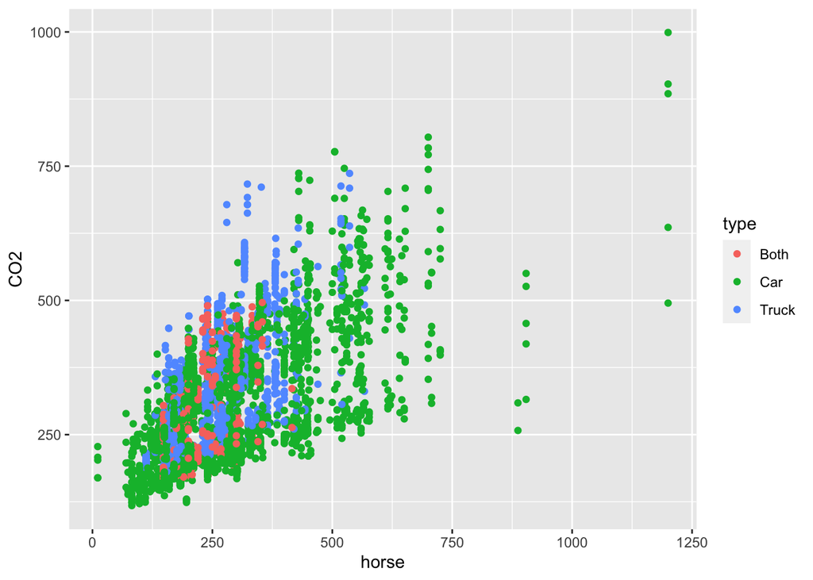

```r
library(ggplot2)
ggplot(epa,aes(x=horse,y=CO2,color=type))+geom_point()
```

Pink is “Both”, Green is “car”, and Blue is “Truck”.

**(c)** Fit a SLR model with `CO2` as the response and only `horse` as the predictor. Recreate your plot and add the fitted regression line. Comment on how well this line models the data. Give an estimate for the average change in `CO2` for a one foot-pound per second increase in `horse` for a vehicle of type `truck`. Give a 95% prediction interval using this model for the `CO2` of a Subaru Impreza Wagon, which is a vehicle with 148 horsepower and is considered type `Both`. (Interestingly, the dataset gives the wrong drivetrain for most Subarus in this dataset, as they are almost all listed as `F`, when they are in fact all-wheel drive.)

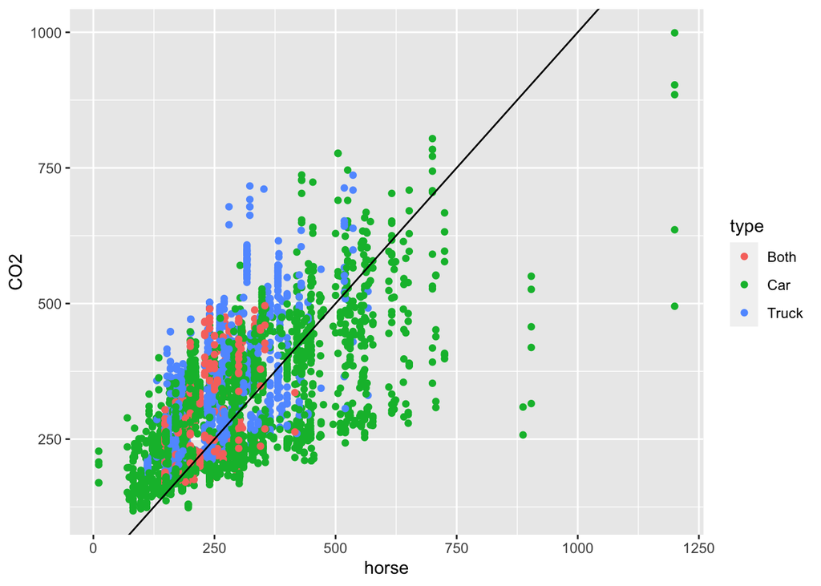

```r
co2_horse_slr = lm(CO2~horse,data=epa)
ggplot(epa,aes(x=horse,y=CO2,color=type))+geom_point()+geom_abline()
```

The line seems to be a good fit for “Both” but not individually.

```r
coef(co2_horse_slr)["horse"]
```

```
##     horse
## 0.5498996
```

An estimate of the average change in CO2 for a 1 ft-lb/s increase in “Horse” for a vehicle of type “truck” is 0.5498996.

```r
newdata = data.frame(horse=148,type="both")
predict(co2_horse_slr, newdata,interval="confidence")
```

```
##       fit      lwr      upr
## 1 236.103 232.2978 239.9082
```

The 95% CI for the Subaru Impreza Wagon is between 232.2978 and 239.9082 for CO2.

**(d)** Fit an additive multiple regression model with `CO2` as the response and `horse` and `type` as the predictors. Recreate your plot and add the fitted regression “lines” with the same colors as their respective points. Comment on how well these lines model the data. Give an estimate for the average change in `CO2` for a one foot-pound per second increase in `horse` for a vehicle of type `truck`. Give a 95% prediction interval using this model for the `CO2` of a Subaru Impreza Wagon, which is a vehicle with 148 horsepower and is considered type `Both`.

```r
co2add = lm(CO2~horse+type,data=epa)
co2add
```

```
##
## Call:
## lm(formula = CO2 ~ horse + type, data = epa)
##
## Coefficients:
## (Intercept)        horse      typeCar    typeTruck
##    155.9821       0.5611     -22.4251      40.0744
```

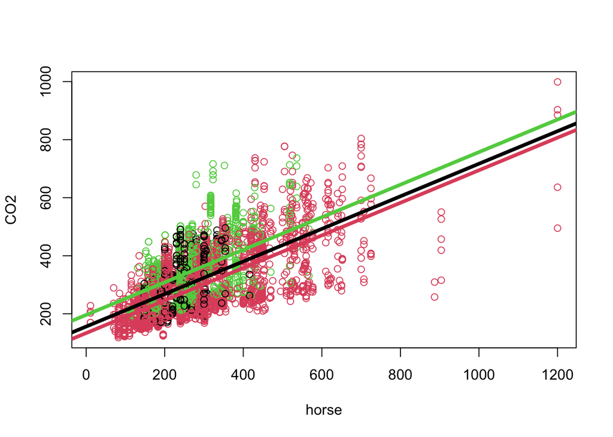

```r
plot(CO2 ~ horse, data=epa,col = type)
#Both
abline(coef(co2add)[1],coef(co2add)[2],col=1 ,lwd=4)
#Car
abline(coef(co2add)[1]+ coef(co2add)[3],coef(co2add)[2], col=2, lwd = 4)
#Truck
abline(coef(co2add)[1]+ coef(co2add)[4],coef(co2add)[2], col=3, lwd=4)
```

These definitely fit better.

```r
coef(co2add)["horse"]
```

```
##     horse
## 0.5611008
```

The estimate for the average change in `CO2` for a one ft-lb/s increase in `horse` for a vehicle of type `truck` is 0.5611008.

```r
newdata = data.frame(horse=148,type="Both")
predict(co2add, newdata, interval="confidence")
```

```
##        fit      lwr      upr
## 1 239.0251 232.1156 245.9345
```

The 95% CI for a Subar Impreza Wagon is between 232.1156 and 245.9345 using the additive model.

**(e)** Fit an interaction multiple regression model with `CO2` as the response and `horse` and `type` as the predictors. Recreate your plot and add the fitted regression “lines” with the same colors as their respective points. Comment on how well these lines model the data. Give an estimate for the average change in `CO2` for a one foot-pound per second increase in `horse` for a vehicle of type `truck`. Give a 95% prediction interval using this model for the `CO2` of a Subaru Impreza Wagon, which is a vehicle with 148 horsepower and is considered type `Both`.

```r
co2int = lm(CO2~horse*type,data=epa)
co2int
```

```
##
## Call:
## lm(formula = CO2 ~ horse * type, data = epa)
##
## Coefficients:
##     (Intercept)            horse          typeCar        typeTruck
##       149.89712          0.58606        -11.17958          7.66404
##   horse:typeCar  horse:typeTruck
##        -0.04286          0.11533
```

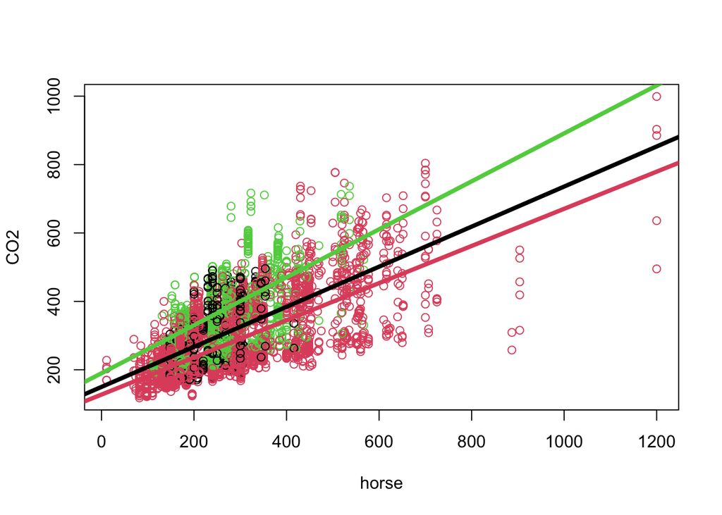

```r
plot(CO2 ~ horse, data=epa,col = type)
#Both
abline(coef(co2int)[1],coef(co2int)[2],col=1 ,lwd=4)
#Car
abline(coef(co2int)[1]+ coef(co2add)[3],coef(co2int)[2]+coef(co2int)[5], col=2, lwd = 4)
#Truck
abline(coef(co2int)[1]+ coef(co2add)[4],coef(co2int)[2]+coef(co2int)[6], col=3, lwd = 4)
```

The regresion fit better in the interaction model.

```r
coef(co2int)["horse"]
```

```
##     horse
## 0.5860597
```

```r
newdata = data.frame(horse=148,type="Both")
predict(co2int, newdata, interval="confidence")
```

```
##        fit      lwr      upr
## 1 236.6339 223.4375 249.8304
```

The 95% CI for a Subar Impreza Wagon is between 223.4375 and 249.8304 using the interaction model.

**(f)** You will perform $F$-tests later in the exercise, but for now, based solely on the three previous plots, which model is preferred: SLR, additive, or interaction?

Based on the plots only, the interaction model is preferred.

**(g)** Use an ANOVA $F$-test to compare the SLR and additive models. Based on this test and a significance level of $\alpha = 0.01$, which model is preferred?

```r
anova(co2_horse_slr,co2add)
```

```
## Analysis of Variance Table
##
## Model 1: CO2 ~ horse
## Model 2: CO2 ~ horse + type
##   Res.Df      RSS Df Sum of Sq      F    Pr(>F)
## 1   4409 35012540
## 2   4407 32054899  2   2957641 203.31 < 2.2e-16 ***
## ---
## Signif. codes:  0 '***' 0.001 '**' 0.01 '*' 0.05 '.' 0.1 ' ' 1
```

Between these two models, the additive model is preferred since the p-value is so low.

**(h)** Use an ANOVA $F$-test to compare the additive and interaction models. Based on this test and a significance level of $\alpha = 0.01$, which model is preferred?

```r
anova(co2add,co2int)
```

```
## Analysis of Variance Table
##
## Model 1: CO2 ~ horse + type
## Model 2: CO2 ~ horse * type
##   Res.Df      RSS Df Sum of Sq      F    Pr(>F)
## 1   4407 32054899
## 2   4405 31894278  2    160621 11.092 1.567e-05 ***
## ---
## Signif. codes:  0 '***' 0.001 '**' 0.01 '*' 0.05 '.' 0.1 ' ' 1
```

Between these two models, the interaction model is preferred due to the low p-value.

## Exercise 2 (Hospital SUPPORT Data)

For this exercise we will use the data stored in `hospital.csv`. It contains a random sample of 580 seriously ill hospitalized patients from a famous study called “SUPPORT” (Study to Understand Prognoses Preferences Outcomes and Risks of Treatment). As the name suggests, the purpose of the study was to determine what factors affected or predicted outcomes, such as how long a patient remained in the hospital. The variables in the dataset are:

- `Days` - Days to death or hospital discharge
- `Age` - Age on day of hospital admission
- `Sex` - female or male
- `Comorbidity` - Patient diagnosed with more than one chronic disease
- `EdYears` - Years of education
- `Education` - Education level; high or low
- `Income` - Income level; high or low
- `Charges` - Hospital charges, in dollars
- `Care` - Level of care required; high or low
- `Race` - Non-white or white
- `Pressure` - Blood pressure, in mmHg
- `Blood` - White blood cell count, in gm/dL
- `Rate` - Heart rate, in bpm

For this exercise, we will use `Charges`, `Pressure`, `Care`, and `Race` to model `Days`.

**(a)** Load the data, and check its structure using `str()`. Verify that `Care` and `Race` are factors; if not, coerce them to be factors. What are the levels of `Care` and `Race`?

```r
hospital = read.csv("hospital.csv")
#str(hospital)
class(hospital$Care)
```

```
## [1] "character"
```

```r
class(hospital$Race)
```

```
## [1] "character"
```

```r
hospital$Care = as.factor(hospital$Care)
hospital$Race = as.factor(hospital$Race)
levels(hospital$Care)
```

```
## [1] "high" "low"
```

```r
levels(hospital$Race)
```

```
## [1] "non-white" "white"
```

**(b)** Fit an additive multiple regression model with `Days` as the response using `Charges`, `Pressure`, `Care`, and `Race` as predictors. What does `R` choose as the reference level for `Care` and `Race`?

```r
daysadd = lm(Days~Charges+Pressure+Care+Race,data=hospital)
coef(daysadd)
```

```
##   (Intercept)       Charges      Pressure       Carelow     Racewhite
## -3.8500692695  0.0001908891  0.1031888688 -0.0964598988  3.0692863280
```

For care, “high” is the reference level. For Race, “non-white” is the reference level.

**(c)** Fit a multiple regression model with `Days` as the response. Use the main effects of `Charges`, `Pressure`, `Care`, and `Race`, as well as the interaction of `Care` with each of the numeric predictors as predictors. (that is, the interaction of `Care` with `Charges` and the interaction of `Care` with `Pressure`). Use a statistical test to compare this model to the additive model using a significance level of $\alpha = 0.01$. Which do you prefer?

```r
days1 = lm(Days~Charges+Pressure+Care+Race+Care:Charges+Care:Pressure,data=hospital)
anova(daysadd,days1)
```

```
## Analysis of Variance Table
##
## Model 1: Days ~ Charges + Pressure + Care + Race
## Model 2: Days ~ Charges + Pressure + Care + Race + Care:Charges + Care:Pressure
##   Res.Df    RSS Df Sum of Sq      F   Pr(>F)
## 1    575 155596
## 2    573 152996  2    2600.2 4.8692 0.008001 **
## ---
## Signif. codes:  0 '***' 0.001 '**' 0.01 '*' 0.05 '.' 0.1 ' ' 1
```

The p-value is under 0.01, so we would say that the new model `day1` is a better fit.

**(d)** Fit a multiple regression model with `Days` as the response. Use the predictors from the model in **(c)** as well as the interaction of `Race` with each of the numeric predictors. (that is, the interaction of `Race` with `Charges` and the interaction of `Race` with `Pressure`). Use a statistical test to compare this model to the additive model using a significance level of $\alpha = 0.01$. Which do you prefer?

```r
days2 = lm(Days~Charges+Pressure+Care+Race+Care:Charges+Care:Pressure+Race:Charges+Race:Pressure,data=hospital)
anova(daysadd,days2)
```

```
## Analysis of Variance Table
##
## Model 1: Days ~ Charges + Pressure + Care + Race
## Model 2: Days ~ Charges + Pressure + Care + Race + Care:Charges + Care:Pressure +
##     Race:Charges + Race:Pressure
##   Res.Df    RSS Df Sum of Sq      F    Pr(>F)
## 1    575 155596
## 2    571 147730  4    7866.6 7.6014 5.699e-06 ***
## ---
## Signif. codes:  0 '***' 0.001 '**' 0.01 '*' 0.05 '.' 0.1 ' ' 1
```

The p-value here is very low, so we prefer the new model.

**(e)** Using the model in **(d)**, give an estimate of the change in average `Days` for a one-unit increase in `Pressure` for a `"white"` patient that required a high level of care.

```r
coef(days2)["Pressure"]+coef(days2)["Pressure:Racewhite"]
```

```
##  Pressure
## 0.1423975
```

**(f)** Find a model using the four predictors that we have been considering that is more flexible than the model in **(d)** and that is also statistically significant as compared to the model in **(d)** at a significance level of $\alpha = 0.01$.

```r
daysint = lm(Days~Charges*Pressure*Care*Race,data=hospital)
anova(days2,daysint)
```

```
## Analysis of Variance Table
##
## Model 1: Days ~ Charges + Pressure + Care + Race + Care:Charges + Care:Pressure +
##     Race:Charges + Race:Pressure
## Model 2: Days ~ Charges * Pressure * Care * Race
##   Res.Df    RSS Df Sum of Sq      F    Pr(>F)
## 1    571 147730
## 2    564 128445  7     19285 12.097 1.969e-14 ***
## ---
## Signif. codes:  0 '***' 0.001 '**' 0.01 '*' 0.05 '.' 0.1 ' ' 1
```

This interaction model is significantly better fit because of the very low p-value.

## Exercise 3 (Fish Data)

For this exercise we will use the data stored in `fish.csv`. It contains data for 158 fish of 7 different species all gathered from the same lake in one season. The variables in the dataset are:

- `Species` - Common name (*Latin name*)
  - 1 = Bream (*Abramis brama*)
  - 2 = Whitewish (*Leuciscus idus*)
  - 3 = Roach (*Leuciscus rutilus*)
  - 4 = (*Abramis bjoerkna*)
  - 5 = Smelt (*Osmerus eperlanus*)
  - 6 = Pike (*Esox Lucius*)
  - 7 = Perch (*Perca fluviatilis*)
- `Weight` - Weight of the fish, in grams
- `Length1` - Length from the nose to the beginning of the tail, in cm
- `Length2` - Length from the nose to the notch of the tail, in cm
- `Length3` - Length from the nose to the end of the tail, in cm
- `HeightPct` - Maximal height as % of Length3
- `WidthPct` - Maximal width as % of Length3
- `Sex` - 0 = female, 1 = male

We will attempt to predict `Weight` using `Length1`, `HeightPct`, and `WidthPct`.

**(a)** Use `R` to fit the model

$$Y = \beta_0 + \beta_1 x_1 + \beta_2 x_2 + \beta_3 x_3 + \beta_4 x_1 x_2 + \beta_5 x_1 x_3 + \beta_6 x_2 x_3 + \beta_7 x_1 x_2 x_3 + \epsilon,$$

where

- $Y$ is `Weight`
- $x_1$ is `Length1`
- $x_2$ is `HeightPct`
- $x_3$ is `WidthPct`.

Report the estimated coefficients of the model.

```r
fish = read.csv("fish.csv")
fishint = lm(Weight~Length1*HeightPct*WidthPct,data=fish)
coef(fishint)
```

```
##                (Intercept)                    Length1
##              -2070.0789433                101.8805290
##                  HeightPct                   WidthPct
##                 99.6568303                137.1369880
##          Length1:HeightPct           Length1:WidthPct
##                 -4.2017983                 -6.3483423
##         HeightPct:WidthPct Length1:HeightPct:WidthPct
##                 -7.9976087                  0.3512455
```

**(b)** Consider fitting a smaller model in `R`.

```r
fish_smaller = lm(Weight ~ Length1 + HeightPct * WidthPct, data = fish)
```

Use a statistical test to compare this model with the previous. Report the following:

- The null and alternative hypotheses in terms of the model given in **(a)**
- The value of the test statistic
- The p-value of the test
- A statistical decision using a significance level of $\alpha = 0.05$
- Which model you prefer

```r
anova(fish_smaller,fishint)
```

```
## Analysis of Variance Table
##
## Model 1: Weight ~ Length1 + HeightPct * WidthPct
## Model 2: Weight ~ Length1 * HeightPct * WidthPct
##   Res.Df     RSS Df Sum of Sq      F    Pr(>F)
## 1    153 2480494
## 2    150 1868778  3    611716 16.367 2.972e-09 ***
## ---
## Signif. codes:  0 '***' 0.001 '**' 0.01 '*' 0.05 '.' 0.1 ' ' 1
```

Null hypothesis: No difference in models. Alternative hypothesis: There is a difference in models. Test Statistic: 16.367 P-value: 2.972e-09 << 0.05 At a significance level of 0.05, we can reject the null hypothesis and find that the interaction significant, therefore the interaction model is preferred.

**(c)** Give an expression based on the model in **(a)** for the true change in average weight for a 1 cm increase in `Length1` for a fish with a `HeightPct` of 20 and a `WidthPct` of 10.

```r
coef(fishint)["Length1"] + coef(fishint)["Length1:HeightPct"]*20 + coef(fishint)["Length1:WidthPct"]*10 + coef(fishint)["Length1:HeightPct:WidthPct"]*20*10
```

```
##  Length1
## 24.61024
```

**(d)** Give an expression based on the smaller model in **(b)** for the true change in average weight for a 1 cm increase in `Length1` for a fish with a `HeightPct` of 20 and a `WidthPct` of 10.

```r
coef(fish_smaller)["Length1"]
```

```
##  Length1
## 31.48522
```

## Exercise 4 ($t$-test Is a Linear Model)

In this exercise, we will try to convince ourselves that a two-sample $t$-test assuming equal variance is the same as a $t$-test for the coefficient in front of a single factor variable in a linear model.

First we setup the data frame that we will use throughout.

```r
n = 16

ex4 = data.frame(
  groups = c(rep("A", n / 2), rep("B", n / 2)),
  values = rep(0, n))
str(ex4)
```

```
## 'data.frame':    16 obs. of  2 variables:
##  $ groups: chr  "A" "A" "A" "A" ...
##  $ values: num  0 0 0 0 0 0 0 0 0 0 ...
```

We will use a total sample size of `16`, `8` for each group. The `groups` variable splits the data into two groups, `A` and `B`, which will be the grouping variable for the $t$-test and a factor variable in a regression. The `values` variable will store simulated data.

We will repeat the following process a number of times.

```r
ex4$values = rnorm(n, mean = 10, sd = 3) # simulate data
summary(lm(values ~ groups, data = ex4))
```

```
##
## Call:
## lm(formula = values ~ groups, data = ex4)
##
## Residuals:
##     Min      1Q  Median      3Q     Max
## -4.1699 -1.3610 -0.2881  1.3855  4.1659
##
## Coefficients:
##             Estimate Std. Error t value Pr(>|t|)
## (Intercept)  10.4792     0.8783  11.932 1.01e-08 ***
## groupsB       0.2063     1.2420   0.166     0.87
## ---
## Signif. codes:  0 '***' 0.001 '**' 0.01 '*' 0.05 '.' 0.1 ' ' 1
##
## Residual standard error: 2.484 on 14 degrees of freedom
## Multiple R-squared:  0.001966,   Adjusted R-squared:  -0.06932
## F-statistic: 0.02758 on 1 and 14 DF,  p-value: 0.8705
```

```r
t.test(values ~ groups, data = ex4, var.equal = TRUE)
```

```
##
##  Two Sample t-test
##
## data:  values by groups
## t = -0.16606, df = 14, p-value = 0.8705
## alternative hypothesis: true difference in means is not equal to 0
## 95 percent confidence interval:
##  -2.870160  2.457645
## sample estimates:
## mean in group A mean in group B
##        10.47920        10.68546
```

We use `lm()` to test

$$H_0: \beta_1 = 0$$

for the model

$$Y = \beta_0 + \beta_1 x_1 + \epsilon$$

where $Y$ are the values of interest, and $x_1$ is a dummy variable that splits the data in two. We will let `R` take care of the dummy variable.

We use `t.test()` to test

$$H_0: \mu_A = \mu_B$$

where $\mu_A$ is the mean for the `A` group, and $\mu_B$ is the mean for the `B` group.

The following code sets up some variables for storage.

```r
num_sims = 100
lm_t = rep(0, num_sims)
lm_p = rep(0, num_sims)
tt_t = rep(0, num_sims)
tt_p = rep(0, num_sims)
```

- `lm_t` will store the test statistic for the test $H_0: \beta_1 = 0$.
- `lm_p` will store the p-value for the test $H_0: \beta_1 = 0$.
- `tt_t` will store the test statistic for the test $H_0: \mu_A = \mu_B$.
- `tt_p` will store the p-value for the test $H_0: \mu_A = \mu_B$.

The variable `num_sims` controls how many times we will repeat this process, which we have chosen to be `100`.

**(a)** Set a seed equal to your UIN. Then write code that repeats the above process `100` times. Each time, store the appropriate values in `lm_t`, `lm_p`, `tt_t`, and `tt_p`. Specifically, each time you should use `ex4$values = rnorm(n, mean = 10, sd = 3)` to update the data. The grouping will always stay the same.

```r
library(broom)
UIN = 662540538
set.seed(UIN)
for(i in 1:num_sims) {
  ex4$values = rnorm(n,mean=10,sd=3)
  lm_t[i] = summary(lm(formula = values ~ groups, data = ex4))$coefficients[2,3]
  lm_p[i] = summary(lm(formula = values ~ groups, data = ex4))$coefficients[2,4]
  tt_t[i] = glance(t.test(values ~ groups, data = ex4, var.equal = TRUE))$statistic
  tt_p[i] = glance(t.test(values ~ groups, data = ex4, var.equal = TRUE))$p.value

}
```

**(b)** Report the value obtained by running `mean(lm_t == tt_t)`, which tells us what proportion of the test statistics are equal. The result may be extremely surprising!

```r
mean(lm_t == tt_t)
```

```
## [1] 0
```

**(c)** Report the value obtained by running `mean(lm_p == tt_p)`, which tells us what proportion of the p-values are equal. The result may be extremely surprising!

```r
mean(lm_p == tt_p)
```

```
## [1] 0.16
```

**(d)** If you have done everything correctly so far, your answers to the last two parts won’t indicate the equivalence we want to show! What the heck is going on here? The first issue is one of using a computer to do calculations. When a computer checks for equality, it demands **equality**; nothing can be different. However, when a computer performs calculations, it can only do so with a certain level of precision. So if we calculate two quantities we know to be analytically equal, they can differ numerically. Instead of `mean(lm_p == tt_p)` run `all.equal(lm_p, tt_p)`. This will perform a similar calculation, but with a very small error tolerance for each equality. What is the result of running this code? What does it mean?

```r
all.equal(lm_p,tt_p)
```

```
## [1] TRUE
```

**(e)** Your answer in **(d)** should now make much more sense. Then what is going on with the test statistics? Take a look at the values stored in `lm_t` and `tt_t`. What do you notice? Is there a relationship between the two? Can you explain why this is happening?

```r
all.equal(tt_t,lm_t)
```

```
## [1] "Mean relative difference: 2"
```